# Respuestas Específicas

Estudio R

Octubre de 2017

## Lectura de datos

```r
load("Icfes162.RData")
```

## 1. ¿Cómo es la distribución de la puntuación en matemáticas, ingles, sociales, naturales y lectura crítica?

### Distribución de la puntuación en matemáticas

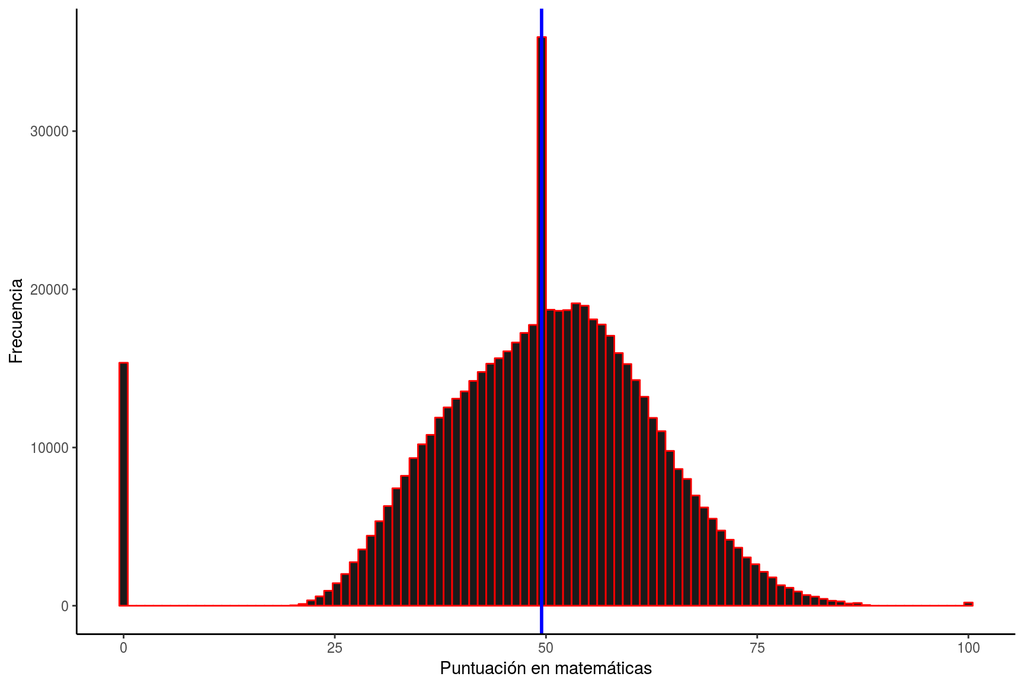

### Distribución de la puntuación en inglés

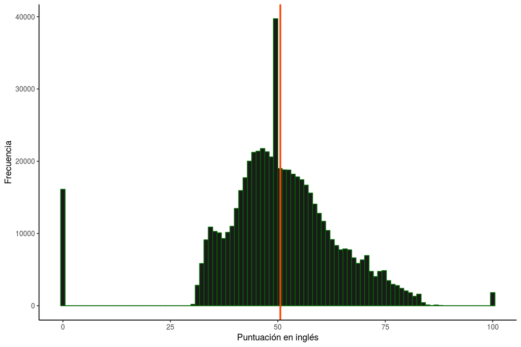

### Distribución de la puntuación en lectura crítca

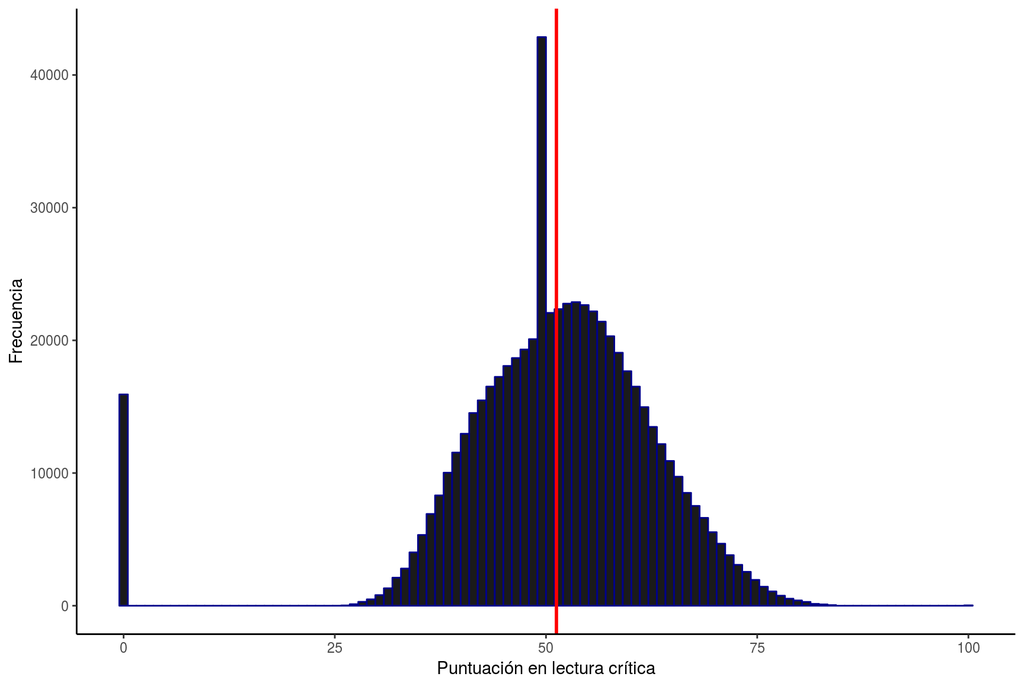

### Distribución de la puntuación en ciencias naturales

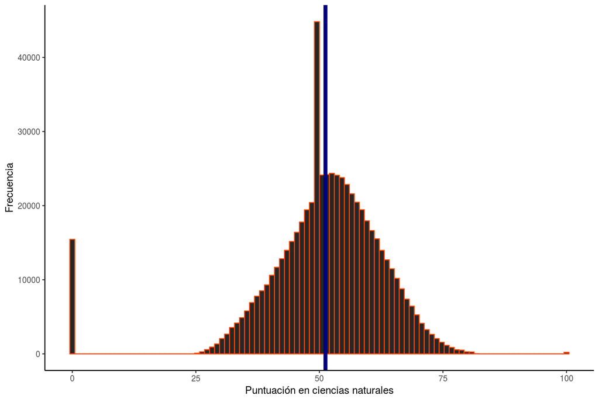

### Distribución de la puntuación en ciencias sociales (ciudadanas)

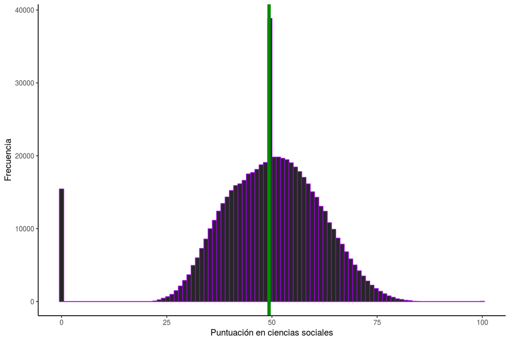

### Distribución de puntuaciones

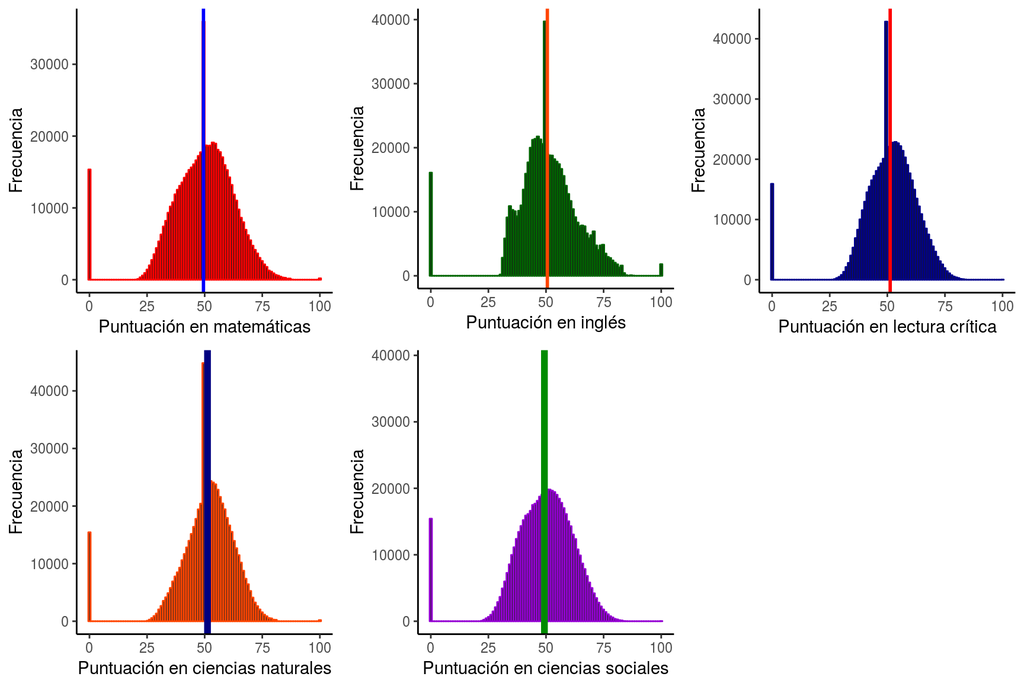

## 2. ¿Cómo es la distribución de las diferentes puntuaciones para hombres y mujeres?

### Distribución puntuación en matemáticas (por género)

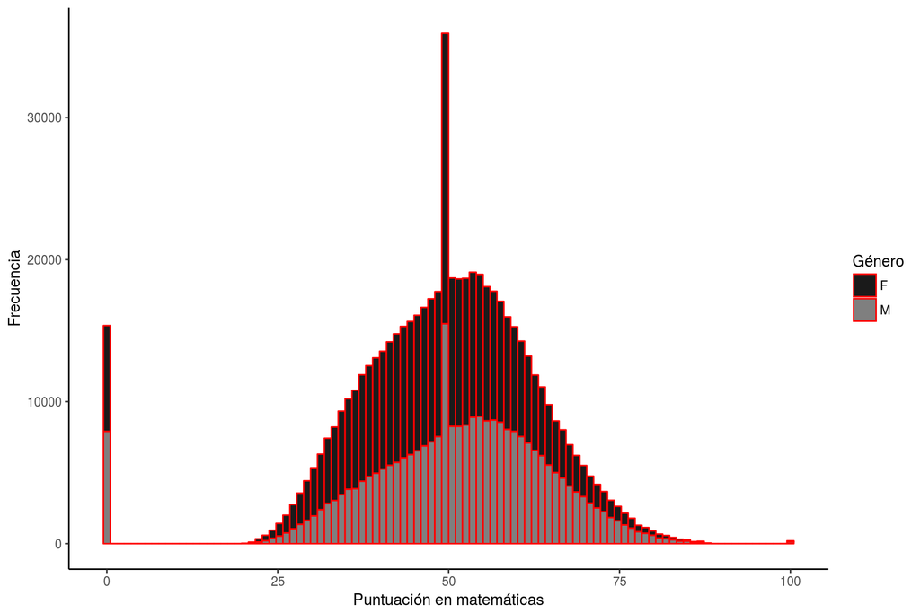

### Distribución puntuación en inglés (por género)

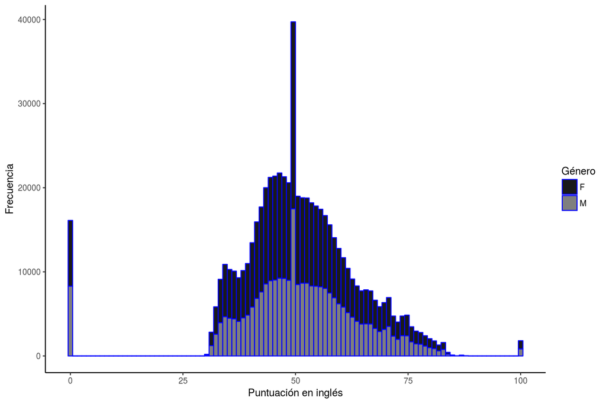

### Distribución puntuación en lectura crítica (por género)

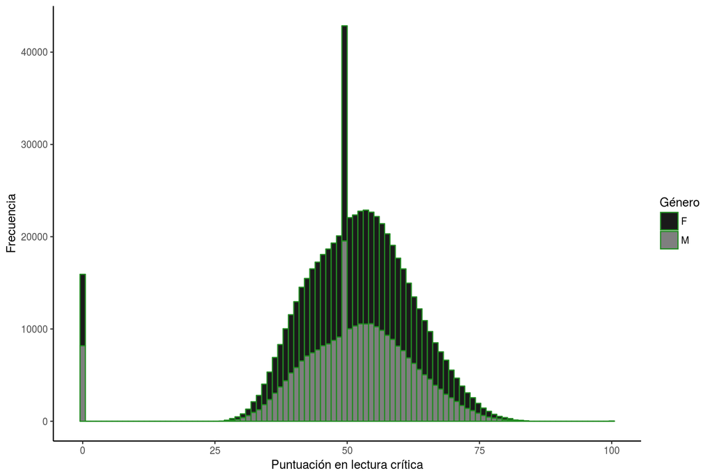

### Distribución puntuación en ciencias naturales (por género)

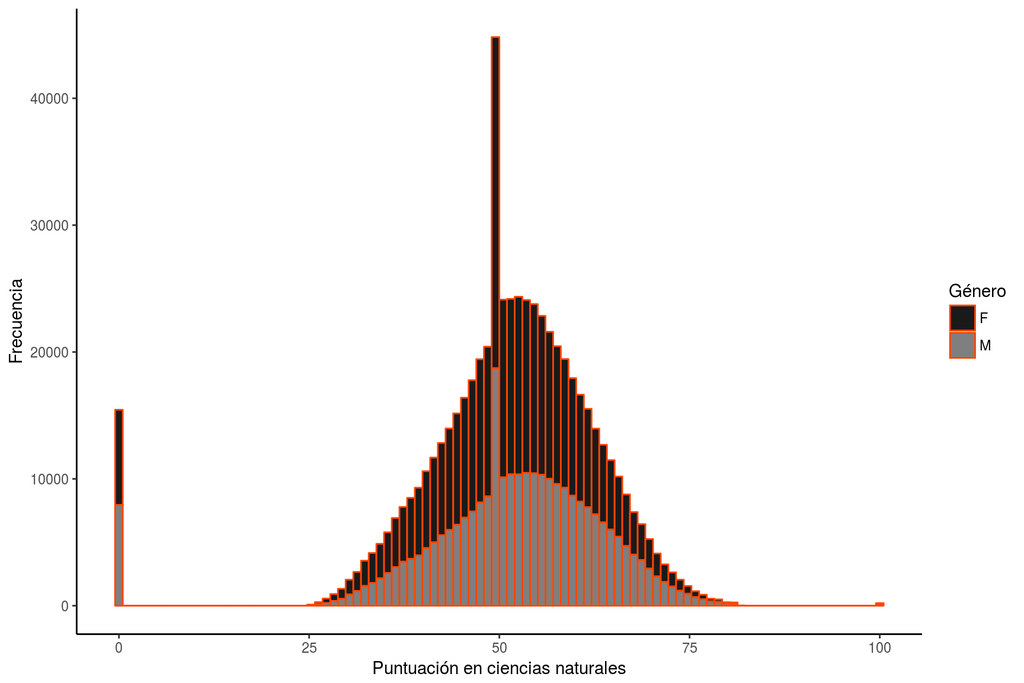

### Distribución puntuación en ciencias sociales (por género)

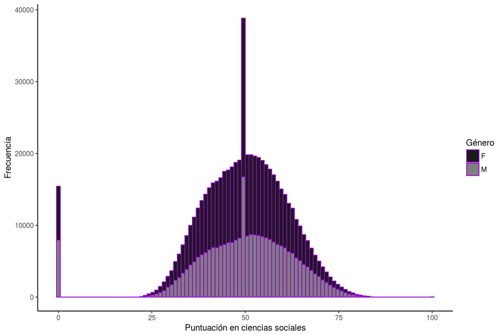

### Distribución de puntuaciónes por género

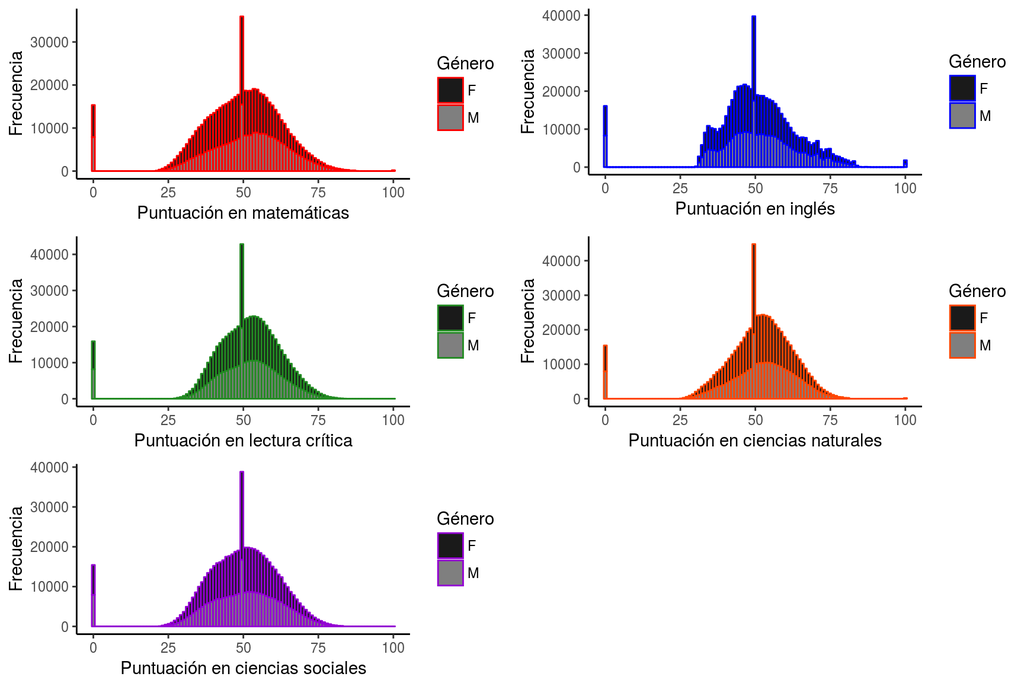

## 3. ¿Cómo es la distribución de las diferentes puntuaciones para estudiantes menores de edad y de colegios oficiales?

### Distribución de la puntuación en matemáticas para menores de edad de colegios oficiales

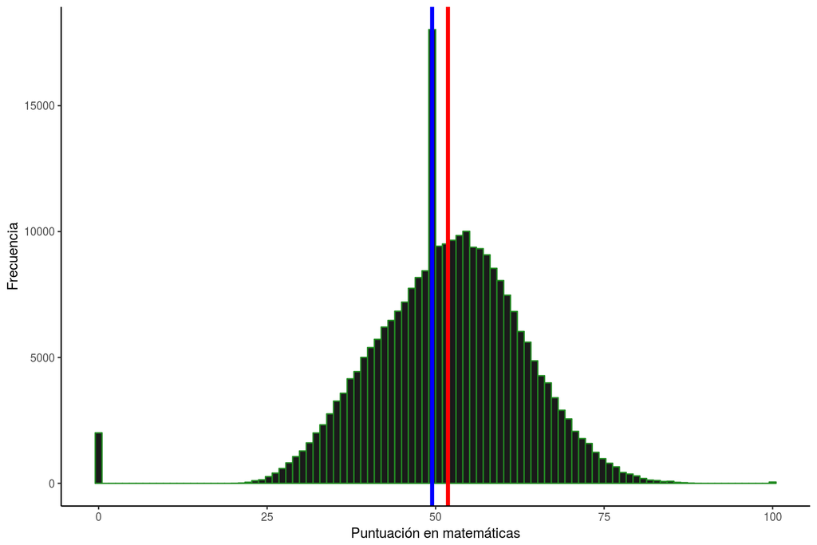

### Distribución de la puntuación en inglés para menores de edad de colegios oficiales

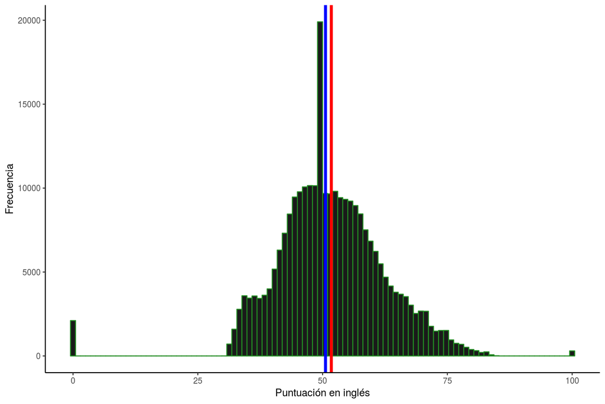

### Distribución de la puntuación en lectura crítca para menores de edad de colegios oficiales

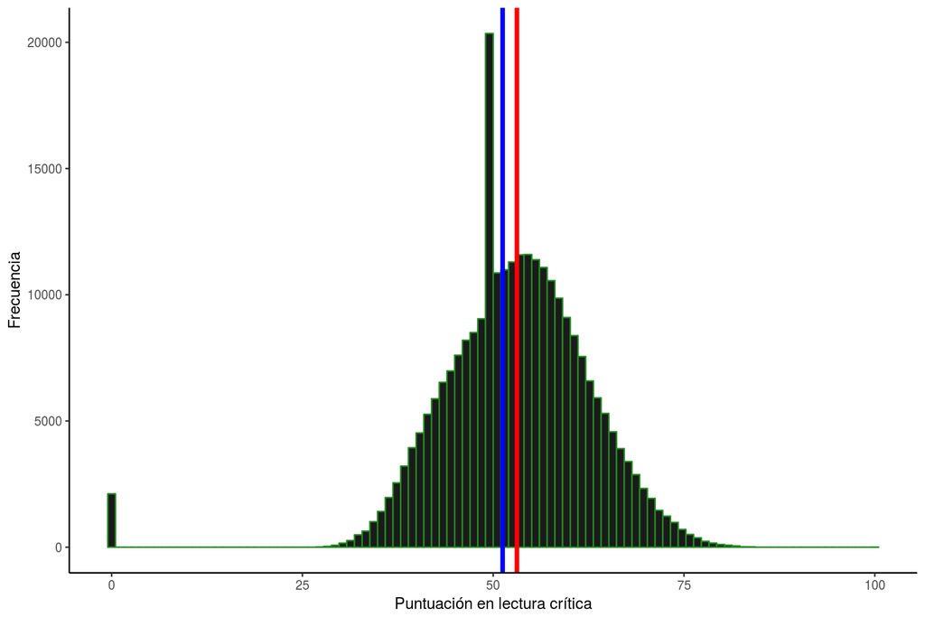

### Distribución de la puntuación en ciencias naturales para menores de edad de colegios oficiales

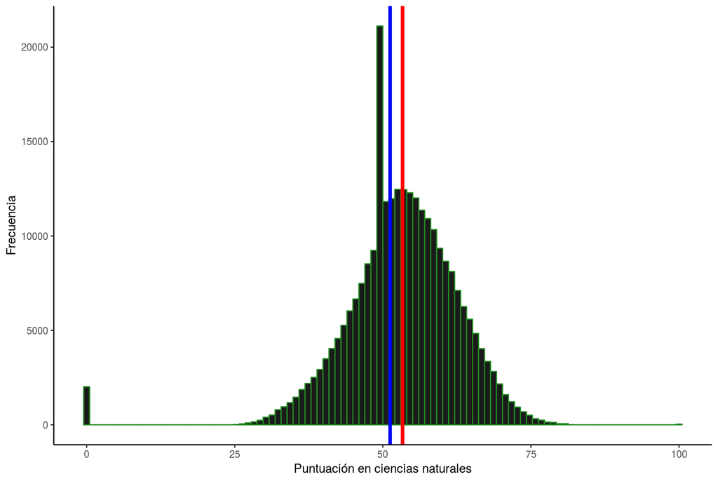

### Distribución de la puntuación en ciencias sociales (ciudadanas) para menores de edad de colegios oficiales

[figure not shown]

### Distribución de puntuaciones en menores de edad de colegios oficiales

[figure not shown]

## 4. Para la puntuación en matemáticas y teniendo en cuenta el área de ubicación del colegio para el departamento de Antioquia, ¿cuál tiene mejor puntuación promedio?

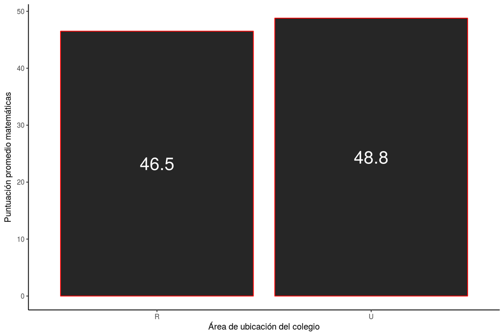

## 5. ¿Alguna de las puntuaciones presenta distribución bimodal o multimodal?

Esta pregunta es posible responderla mediante el análisis de las gráficas construidas en numerales anteriores.

## 6. ¿En qué departamento están los percentiles más altos?

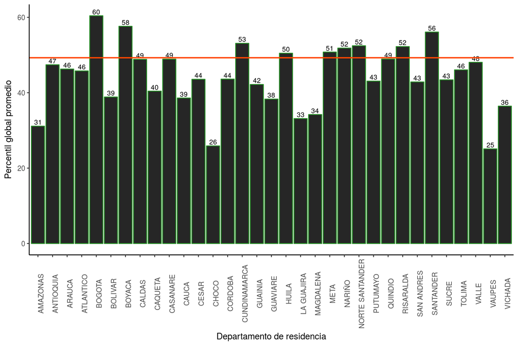

### Los 10 departamentos con percentiles globales promedios más altos

| ESTU_RESIDE_DEPTO | Promedio |
| --- | --- |
| BOGOTA | 60.42 |
| BOYACA | 57.62 |
| SANTANDER | 56.1 |
| CUNDINAMARCA | 53.1 |
| NORTE SANTANDER | 52.46 |
| RISARALDA | 52.24 |
| NARIÑO | 51.84 |
| META | 50.79 |
| HUILA | 50.48 |
| QUINDIO | 48.93 |

## 7. Para la puntuación en matemáticas, ¿hay alguna diferencia en promedio para los estratos?

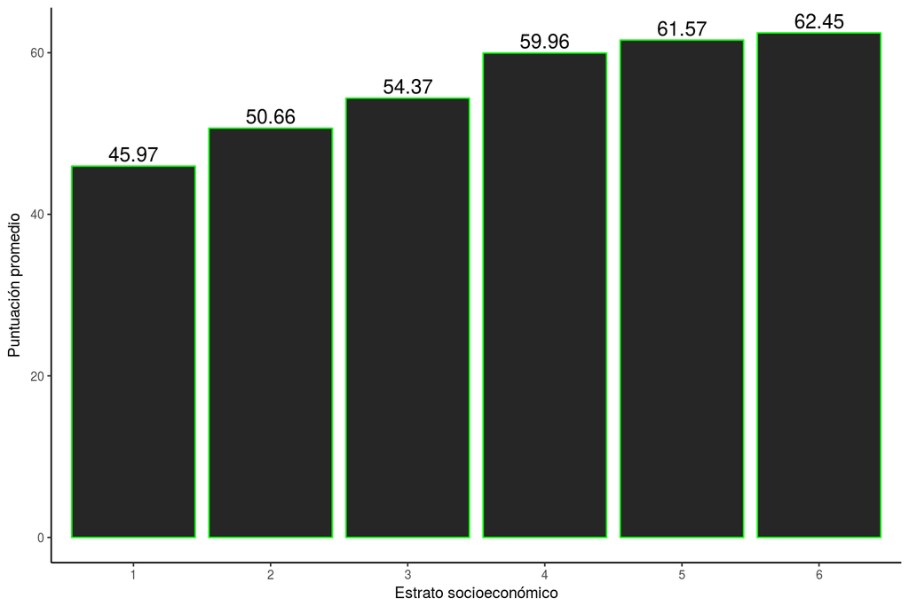

## 8. ¿Cules son los 100 estudiantes con los mejores percentiles globales?

|  | COLE_NOMBRE_SEDE | COLE_COD_MCPIO_UBICACION | COLE_JORNADA | COLE_GENERO | COLE_CARACTER | COLE_NATURALEZA | ESTU_AREA_RESIDE | ESTU_EDAD | ESTU_GENERO | ESTU_TRABAJA | ESTU_RESIDE_DEPTO | ESTU_RESIDE_MCPIO | PERCENTIL_GLOBAL |
| --- | --- | --- | --- | --- | --- | --- | --- | --- | --- | --- | --- | --- | --- |
| 1 | GIMNASIO CAMPESTRE LA FONTANA(ANTES EL PRINCIPITO) | 50001 | C | MIXTO | ACADÉMICO | NO OFICIAL | U | 16 | F | 1 | META | VILLAVICENCIO | 100 |
| 2 | COLEGIO PADRE RAMON ARCILA R | 5631 | C | MIXTO | ACADÉMICO | NO OFICIAL | U | 16 | F | 1 | ANTIOQUIA | SABANETA | 100 |
| 3 |  |  |  |  |  | OTRO | U | 18 | M |  | BOGOTA | BOGOTÁ D.C. | 100 |
| 4 | COLEGIO IDPHU BILINGUE DE SANTA MARTA | 47001 | C | MIXTO | ACADÉMICO | NO OFICIAL | U | 16 | M | 1 | MAGDALENA | SANTA MARTA | 100 |
| 5 | INSTITUCION EDUCATIVA TERCER MILENIO | 70215 | C | MIXTO | ACADÉMICO | NO OFICIAL | U | 16 | M | 1 | SUCRE | COROZAL | 100 |
| 6 | CENT EDUC DIST RAFAEL NUÑEZ | 11001 | M | MIXTO | ACADÉMICO | OFICIAL | U | 16 | M | 1 | BOGOTA | BOGOTÁ D.C. | 100 |
| 7 | COLEGIO LA ENSEÑANZA | 81001 | M | MIXTO | ACADÉMICO | NO OFICIAL | U | 15 | F | 1 | ARAUCA | ARAUCA | 100 |
| 8 | COLEGIO LA PRESENTACION | 5615 | C | MIXTO | ACADÉMICO | NO OFICIAL | U | 16 | F | 1 | ANTIOQUIA | RIONEGRO | 100 |
| 9 | GIMNASIO PALMA REAL | 17380 | M | MIXTO | ACADÉMICO | NO OFICIAL | U | 16 | F | 1 | CALDAS | LA DORADA | 100 |
| 10 | COL CRISTIANO GRACIA Y AMOR - SEDE PRINCIPAL | 11001 | C | MIXTO | ACADÉMICO | NO OFICIAL | U | 16 | M | 1 | BOGOTA | BOGOTÁ D.C. | 100 |

[output cut: 90 more lines]

## 9. En la capital, ¿cuál fue la disciplina de mayor y menor puntuación promedio?

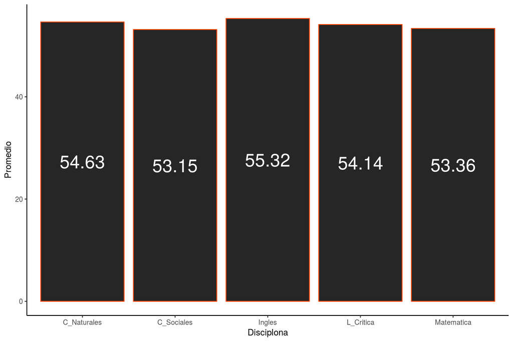

## 10. Si se piensa en ciudades turísticas (las que usted considere como tal), ¿tienen mayor o menor puntuación en ingles respecto a otras ciudades?

Para elegir las ciudades turísticas (en este caso) se utilizó el [comunicado de prensa del DANE](http://www.dane.gov.co/files/investigaciones/boletines/EVI/cp_EVI_sep_12_ago13.pdf) para el año 2012 (septiembre) -2103 (agosto) -datos preliminares- (“último” comunicado accesible en la web), reflejando recepción mayoritaria de turistas extranjeros en:

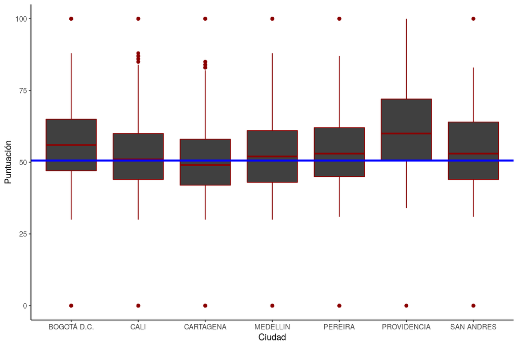

### Puntuación promedio en inglés

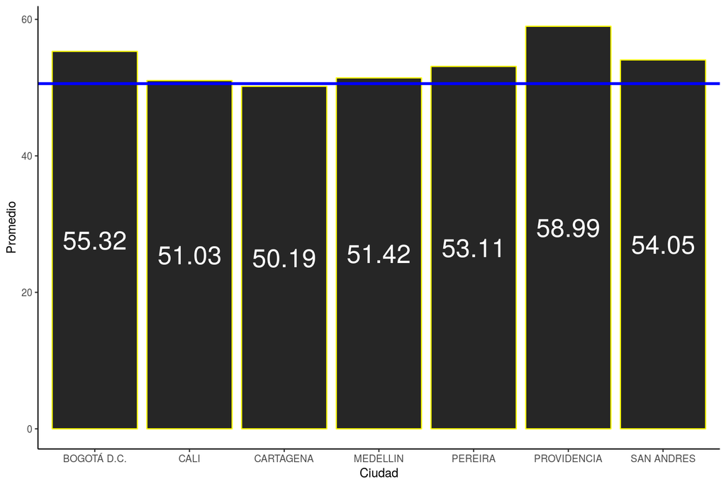

## 11. Teniendo en cuenta el percentil global, ¿cómo son los resultados de personas con internet y computador?

### Número de registros (%)

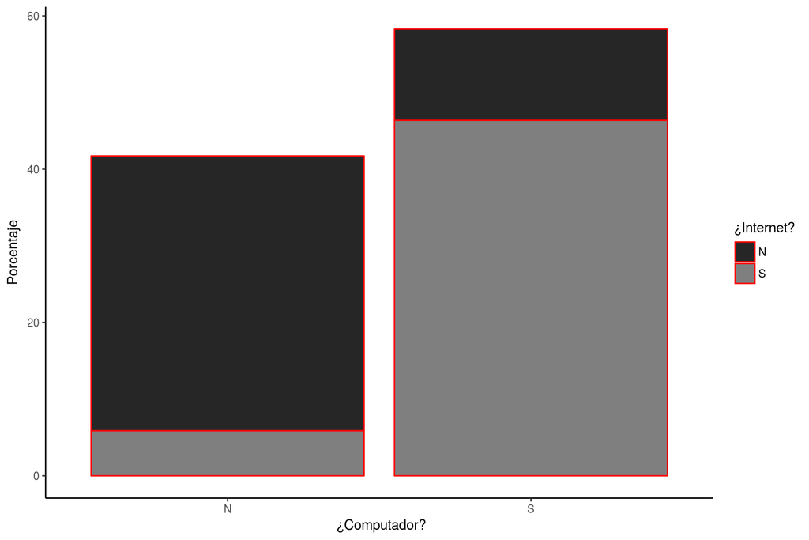

### Percentil global promedio

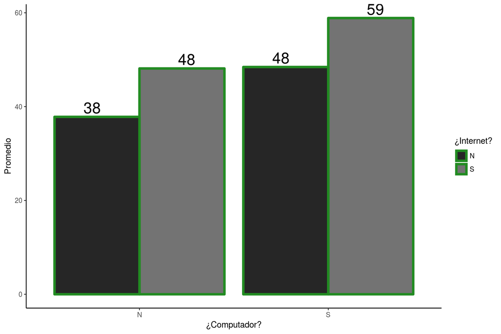

## 12. ¿Personas que tienen más libros en casa presentan puntuación en lectura crítica mayor o menor respecto a los que tienen menos libros en casa?

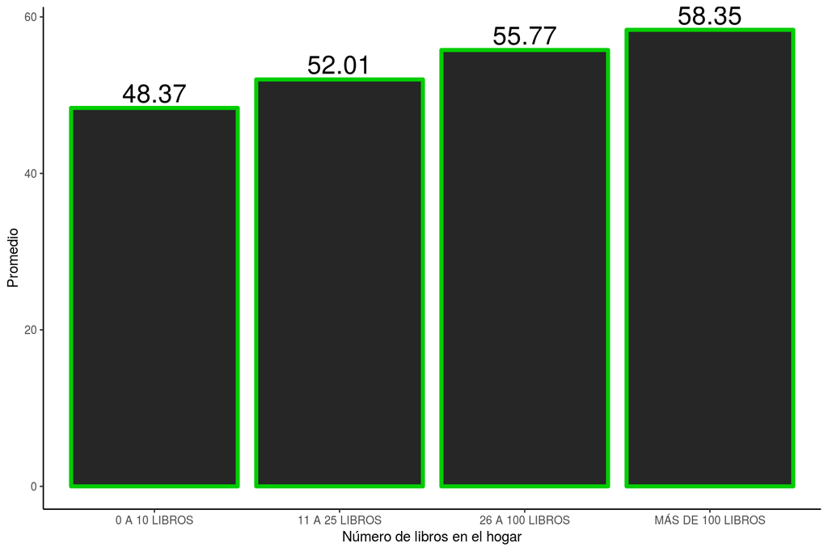